# Wprowadzenie do programowania w R

### 3.2.2. Wektory domyślne pakietu bas

Zanim przejdziemy dalej poznamy kilka tzw. domyślnych wektorów pakietu `base` z których będziemy później korzystać.

```r
letters # małe litery
```

```
##  [1] "a" "b" "c" "d" "e" "f" "g" "h" "i" "j" "k" "l" "m" "n" "o" "p" "q"
## [18] "r" "s" "t" "u" "v" "w" "x" "y" "z"
```

```r
LETTERS # duże litery
```

```
##  [1] "A" "B" "C" "D" "E" "F" "G" "H" "I" "J" "K" "L" "M" "N" "O" "P" "Q"
## [18] "R" "S" "T" "U" "V" "W" "X" "Y" "Z"
```

```r
month.name # nazwy miesięcy
```

```
##  [1] "January"   "February"  "March"     "April"     "May"
##  [6] "June"      "July"      "August"    "September" "October"
## [11] "November"  "December"
```

```r
month.abb # skrócone j.w.
```

```
##  [1] "Jan" "Feb" "Mar" "Apr" "May" "Jun" "Jul" "Aug" "Sep" "Oct" "Nov"
## [12] "Dec"
```

```r
pi #
```

```
## [1] 3.141593
```

Możemy oczywiściue stworzyć polskie nazwy miesięcy, ale jest to trochę bardziej skomplikowane.

```r
format(ISOdate(2000, 1:12, 1), "%B")
```

```
##  [1] "styczeń"     "luty"        "marzec"      "kwiecień"    "maj"
##  [6] "czerwiec"    "lipiec"      "sierpień"    "wrzesień"    "październik"
## [11] "listopad"    "grudzień"
```

```r
format(ISOdate(2000, 1:12, 1), "%b")
```

```
##  [1] "sty" "lut" "mar" "kwi" "maj" "cze" "lip" "sie" "wrz" "paź" "lis"
## [12] "gru"
```

Funkcja `ISOdate()` generuje wektor daty, skłądajacy się z pierwszego dnia każdego miesiąca.

```r
czas <- ISOdate(year = 2000, month = 1:12, day = 1)
czas
```

```
##  [1] "2000-01-01 12:00:00 GMT" "2000-02-01 12:00:00 GMT"
##  [3] "2000-03-01 12:00:00 GMT" "2000-04-01 12:00:00 GMT"
##  [5] "2000-05-01 12:00:00 GMT" "2000-06-01 12:00:00 GMT"
##  [7] "2000-07-01 12:00:00 GMT" "2000-08-01 12:00:00 GMT"
##  [9] "2000-09-01 12:00:00 GMT" "2000-10-01 12:00:00 GMT"
## [11] "2000-11-01 12:00:00 GMT" "2000-12-01 12:00:00 GMT"
```

Funkcja `format()` zmienia format wyswietlania na `"%B"`.

```r
czas <- format(czas, "%B")
czas
```

```
##  [1] "styczeń"     "luty"        "marzec"      "kwiecień"    "maj"
##  [6] "czerwiec"    "lipiec"      "sierpień"    "wrzesień"    "październik"
## [11] "listopad"    "grudzień"
```

Więcej o formatowaniu daty znajdziesz w pomocy dla funkcji `strptime()`

##### Ćwiczenie 4

###### Treść

Wygeneruj nazwy dni tygodnia, korzystając z pomocy funkcji `strptime()` oraz funkcji `format()` i `ISOdate()`.

###### Odp.

```r
format(ISOdate(year = 2000, month = 1, day = 3:9), "%A")
```

```
## [1] "poniedziałek" "wtorek"       "środa"        "czwartek"
## [5] "piątek"       "sobota"       "niedziela"
```

```r
format(ISOdate(year = 2000, month = 1, day = 3:9), "%a")
```

```
## [1] "pon."   "wt."    "śr."    "czw."   "pt."    "sob."   "niedz."
```

##### Ćwiczenie 5

###### Treść

Utwórz po dwa wektory liczbowe i tekstowe i mieszane korzystając z funkcji `c()`, `seq()`, `rep()`, opratora `:`, oraz poznanych wektorów tekstowych. Jeden wektor powinien zawierać wartości losowe z wektora tekstowego (Funkcja `sample()`, sprawdźć w pomocy)

###### Odp.

Kilka przykąłdowych odpowiedzi:

```r
c(1,2,3,4,5:8)
```

```
## [1] 1 2 3 4 5 6 7 8
```

```r
c(seq(1,9,0.8), rep(c(8,3,75,21), len = 10))
```

```
##  [1]  1.0  1.8  2.6  3.4  4.2  5.0  5.8  6.6  7.4  8.2  9.0  8.0  3.0 75.0
## [15] 21.0  8.0  3.0 75.0 21.0  8.0  3.0
```

```r
c(1:4, seq(0.1,0.5, length.out = 7), rep(6:2), 3)
```

```
##  [1] 1.0000000 2.0000000 3.0000000 4.0000000 0.1000000 0.1666667 0.2333333
##  [8] 0.3000000 0.3666667 0.4333333 0.5000000 6.0000000 5.0000000 4.0000000
## [15] 3.0000000 2.0000000 3.0000000
```

```r
sample(x = letters, replace = F, size = 10)
```

```
##  [1] "t" "f" "u" "j" "a" "d" "h" "v" "y" "b"
```

##### Zastosowanie sekwencji

###### Treść

1. Funkcją `exp()` policzmy eksponentę (eksponenta, inaczej funkcja wykładnicza, to bardzo szybko rosnąca funkcja matematyczna) z sekwencji.
2. Następnie - wykorzystując funkcję `plot()` - narysujmy sekwencję i jej eksponentę.
3. Zauważmy, że argumentem tej funkcji jest wektor, a ponieważ większość operacji w R jest wektoryzowana, funkcja exp() policzy eksponentę dla każdego elementu wektora sekwencja.

###### Wykonanie

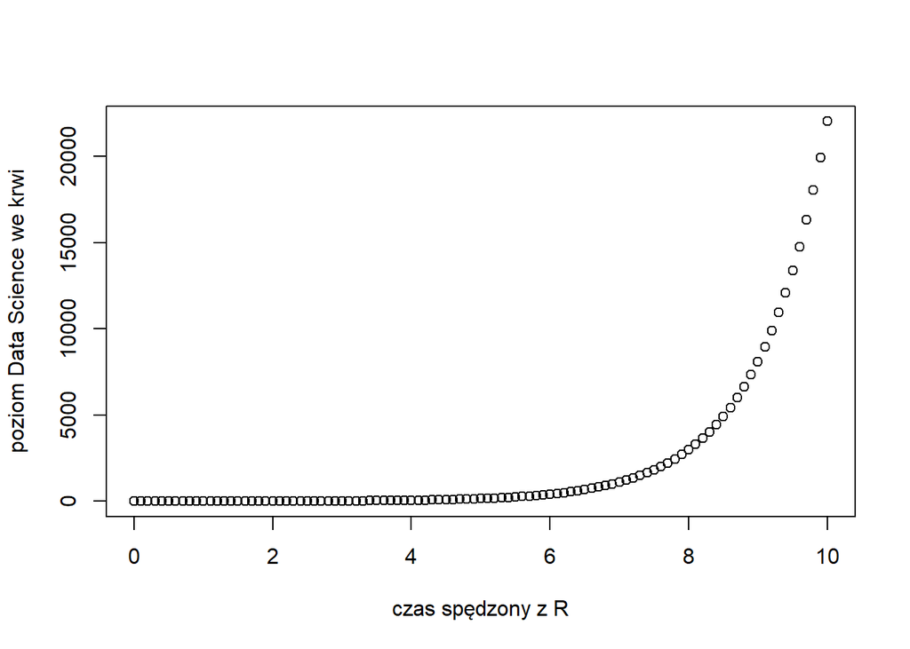

```r
sekwencja <- seq(0, 10, 0.1) # sekwencja liczb
poziom <- exp(sekwencja) # każdą liczby sekwencji(x) podnosimy do ^e

plot(x = sekwencja,   # wartosci osi x
     y = poziom,      # wartości osi y
     xlab="czas spędzony z R",           # etykieta x
     ylab="poziom Data Science we krwi") # etykieta y
```

Domyślnie utworzono wykres punktowy. Argumentem `type` możemy zmienić typ wykresu np. na liniowy `type = "l"`

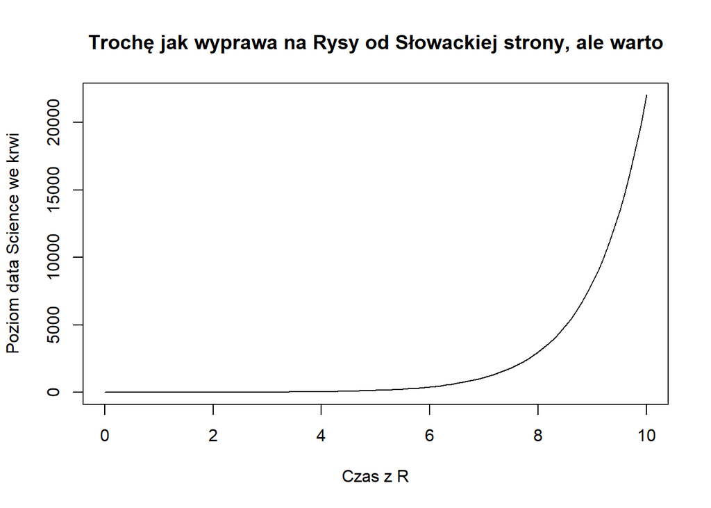

```r
plot(x = sekwencja, y = poziom,
     xlab= "Czas z R",
     ylab= "Poziom data Science we krwi",
     type ="l",
     main = "Trochę jak wyprawa na Rysy od Słowackiej strony, ale warto")
```

##### Ćwiczenie 6

###### Treść

Skoro umiesz już tworzyć proste wykresy, to wykreśl kilka funkcji:

- dla pierwiastkowania wektora sekwencji
- sekwencja do potęgi drugiej
- sekwencja po potęgi czwartej
- logarytm naturalny sekwencji
- logarytm dziesiętny sekwencji
- silnia z sekwencji (`factorial()`)

###### Wykonanie

[figure not shown]

```r
sek <- seq(0, 10, 0.1) # sekwencja liczb

plot(x = sek[1:20],
     y = sqrt(sek)[1:20], type = "b")

plot(x = sek,
     y = sek^2, type = "l")

plot(x = sek,
     y = sek^4, type = "p")

plot(x = sek,
     y = log(sek))

plot(x = sek,
     y = log10(sek))

plot(x = sek,
     y = factorial(sek))
```